# Computing the Information Matrix

Guillaume Blanc

6 septembre 2021

# Monte Carlo Computation of the Information Matrix

The asymptotic variance $\text{AVAR}(\theta)$ of an M-estimator can be written as:

$$\text{AVAR}(\theta) = A(\theta)^{-1}B(\theta) \left[A(\theta^{-1})\right]^{\top}$$
where

$$A(\theta) = \mathbb E_Y \left[H(\theta, Y)\right], \\
B(\theta) = \mathbb E_Y \left[s(\theta, Y)s(\theta, Y)^\top\right]$$

where $s(\theta, Y) = \frac{\partial \log l(\theta, Y)}{\partial\theta}$ is the score function $H(\theta, Y) = - \frac{\partial s(\theta, Y)}{\partial \theta^\top}$ is a the $p\times p$ hessian matrix.

For the MLE, $A(\theta) = B(\theta)$, and thus its $\text{AVAR}$ can be computed by either $A(\theta)^{-1}$ or $B(\theta)^{-1}$.

$$\hat H_{(i)} = \frac{1}{2}\left\{
\frac{s_{(i)}}{2}\left[\Delta_{(i)1}^{-1}, \Delta_{(i)2}^{-1}, \cdots, \Delta_{(i)p}^{-1}\right] +
\left(\frac{s_{(i)}}{2}\left[\Delta_{(i)1}^{-1}, \Delta_{(i)2}^{-1}, \cdots, \Delta_{(i)p}^{-1}\right]\right)^\top\right\},$$
where $s_{(i)} \equiv s(\theta + \Delta_{(i)}, Y_{\text{pseudo}}(i)) - s(\theta - \Delta_{(i)}, Y_{\text{pseudo}}(i))$ and the perturbation vector $\Delta_{(i)} \equiv \left[\Delta_{(i)1}^{-1}, \Delta_{(i)2}^{-1}, \cdots, \Delta_{(i)p}^{-1}\right]^\top$ is a vector of bernoulli random variables multiplied by a small scalar $c$. As noted by Spall 2005, $\hat H_{(i)}$ is a nearly unbiased estimator of the unknown $H$, which allows to estimate $A(\theta)$ as

$$\hat A(\theta, N) = \frac{1}{N} \sum_{i=1}^N \hat H_{(i)}.$$

The bias can be shown to be of order $O(c^2)$: the estimation can thus be made better by reducing $c$ and increasing $N$. Spall (2005) has found $c=0.0001$ to be effective.

The obvious advantage of this method is that the computations of $\hat H_{(i)}$ only requires $2$ evaluations of the score $s$, irrespective of the dimensions $p$.

Let us implement the method.

## Implementation

```r
  # The following code is written with readability in mind, not computational efficiency.
  # Tremendous computational speedups can be obtained by, for instance, vectorizing the methods.

compute_hessian_estimator <- function(score, theta, Y, c){
  p <- length(theta)
  perturbation <- sample(c(-c,c), p, replace = T)
  Gk <- score(theta  + perturbation, Y) - score(theta - perturbation, Y)
  Hk <- Gk %*% t(1/perturbation)
  Hk <- 1/2 * (Hk/2 + t(Hk/2))
  Hk
}
compute_expected_hessian <- function(generator, score, theta, N, c=1e-4){
  # Returns an estimate of the expectation of the hessian
  # Generator is a function that takes theta and returns a matrix whose rows are the realizations from the true model.
  # Score is a function that takes theta and an observation Y, and returns a p-vector
  # theta is a p-vector of parameters
  # N is the number of summands to compute the final hessian.

  # Extract information from the arguments
  p <- length(theta)

  # Generate the realizations
  Y <- generator(theta, N)

  H <- matrix(0, p, p)
  # The sum is computed sequentially to reduce the memory requirements
  for(i in 1:N){
    H <- H + compute_hessian_estimator(score, theta, Y[i,], c=c)
  }
  H <- H/N
  list(H = H)
}
```

Let's check an example when the model of the data is multivariate gaussian with mean $\mu = \theta$ and known variance-covariance $\Sigma$. The score of the MLE for $\theta$ is:

$$s(\theta, Y) = - \Sigma^{-1} (Y - \mu)$$
For the MLE, it is easy to see that

$$A(\theta) = \mathbb E_Y\left[ \Sigma^{-1}\right] = \Sigma^{-1}$$
$$B(\theta) = \mathbb E_Y\left[-\Sigma^{-1} (Y- \mu)\left(-\Sigma^{-1} (Y- \mu)\right)^\top\right] = \Sigma^{-1}\mathbb E_Y\left[(Y- \mu)\left((Y- \mu)\right)^\top\right] \Sigma^{-1} = - \Sigma^{-1}\Sigma\Sigma^{-1} = \Sigma^{-1}$$
We'll use this simple example to check the above methodology.

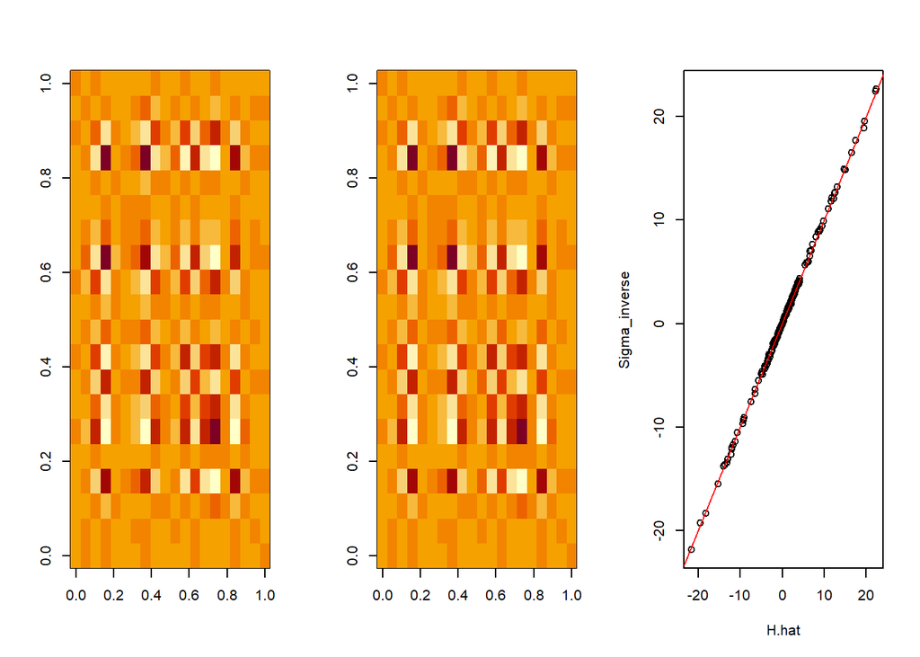

```r
generator <- function(theta, N){
  mvtnorm::rmvnorm(N, mean=theta, sigma=Sigma)
}

score_MLE <- function(theta, Y){
  if(!is.vector(Y)) stop("Y must be provided as a vector, not a matrix.")
  as.vector(- Sigma_inverse %*% (Y - theta))
}

set.seed(2131)
N <- 10000
p <- 20
theta <- 1:p
# add some randomness
Sigma <- diag(2, p)
Sigma <- rWishart(1, p, diag(p))[,,1]/sqrt(p)
Sigma_inverse <- solve(Sigma)

H.hat <- compute_expected_hessian(generator=generator, score=score_MLE, theta=theta, N=N, c=1e-04)$H

# This should be close to Sigma_inverse

par(mfrow=c(1,3))
image(Sigma_inverse[,p:1])
image(H.hat[,p:1])
plot(H.hat, Sigma_inverse); abline(a=0, b=1, col=2)
```

```r
par(mfrow=c(1,1))
```

Although the example is simple and possibly favorable to the method, the results are (surprisingly?) convincing.